# Analysis

### Circularized Gaussian Kernel Density Estimation (KDE)

Besides the traditional cosinor-based methodology, ActiGlobe also offers circularized Gaussian kernel density estimation. In contrast to the traditional cosinor method, KDE is nonparametric apporach allowing the model to better respect the intensity and the duration of the underlying rest-activity patterns, without forcing a sinusoidal shape. To facilitate transition from cosinor model, we designed to generate cosinor-like parameters by projecting the model onto an imaginary cosinor plane.

```r
fit.KDE <-
  CosinorM.KDE(time = df$Time,
             activity = df$Activity)

### Look at the parameters
fit.KDE$coef.cosinor
```

```
#>         MESOR     Amplitude     Acrophase  Acrophase.hr          Beta
#>  40633.530211  34124.265902     -2.896002    -11.061912 -33100.326700
#>         Gamma
#>  -8296.619533
```

#### Visualized Model Comparisons

```r
### For external graphic plot.
library(ggplot2)
```

##### OLS-Cosinor vs. Kernel Density Estimation

When we plot the KDE alongside the cosinor we can immediately see skew, broad or narrow peaks, and multiple active periods that the single‑harmonic cosinor cannot represent.

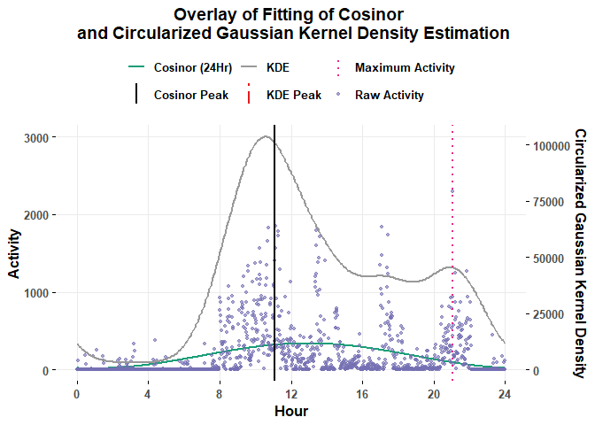

```r
# Prepare data
n <- length(fit.ols$fitted.values)
plot_df <- data.frame(
  hour = seq(0, 24, length.out = n),
  fitted = as.numeric(fit.ols$fitted.values),
  activity = df$Activity
)

# Cosinor and true-peak hours
phi <- fit.ols$coef.cosinor[3]
cosinor_peak_hour <- (24 - (phi %% (2 * pi)) * 24 / (2 * pi)) %% 24
true_peak_hour <- plot_df$hour[which.max(df$Activity)]

# Kernel density (assumes kdf$hour in hours)
kdf_plot <- data.frame(hour = fit.KDE$kdf$hour, density = fit.KDE$kdf$density)
y_primary_max <- 3000
kdf_plot$density_scaled <- kdf_plot$density / max(kdf_plot$density) * y_primary_max

# KDE vline location
kde_vline_hour <- fit.KDE$coef.cosinor["Acrophase.hr"]

# Named colours for mapping
my_cols <- c(
  "Raw Activity"     = "#7570b3",
  "Cosinor (24Hr)"   = "#1b9e77",
  "KDE"   = "#999999",
  "Cosinor Peak"     = "black",
  "Maximum Activity" = "#e7298a",
  "KDE Peak"         = "#e41a1c"
)

ggplot() +
  # Lines/points with color mapped to a fixed name so they appear in legend
  geom_line(data = plot_df, aes(x = hour, y = fitted, color = "Cosinor (24Hr)"), size = 0.9) +
  geom_point(data = plot_df, aes(x = hour, y = activity, color = "Raw Activity"), size = 1.0, alpha = 0.6) +
  geom_line(data = kdf_plot, aes(x = hour, y = density_scaled, color = "KDE"), size = 1) +
  # vertical lines mapped to colour names so they appear in the legend
  geom_vline(aes(xintercept = cosinor_peak_hour, color = "Cosinor Peak"), linetype = "solid", size = 1) +
  geom_vline(aes(xintercept = true_peak_hour, color = "Maximum Activity"), linetype = "dotted", size = 1) +
  geom_vline(aes(xintercept = kde_vline_hour, color = "KDE Peak"), linetype = "longdash", size = 1) +
  # scales and labels
  scale_x_continuous(
    name = "Hour",
    limits = c(0, 24),
    breaks = c(0, 4, 8, 12, 16, 20, 24),
    labels = c(0, 4, 8, 12, 16, 20, 24)
  ) +
  scale_y_continuous(
    name = "Activity",
    limits = c(0, y_primary_max),
    sec.axis = sec_axis(~ . / y_primary_max * max(kdf_plot$density), name = "Circularized Gaussian Kernel Density")
  ) +
  scale_color_manual(name = NULL, values = my_cols) +
 ggtitle("Overlay of Fitting of Cosinor \n and Circularized Gaussian Kernel Density Estimation") +

  theme_minimal(base_size = 12) +
  theme(
    text = element_text(face = "bold"),
    plot.title = element_text(hjust = 0.5, face = "bold"),
    axis.title = element_text(face = "bold"),
    axis.text = element_text(face = "bold"),
    legend.title = element_text(face = "bold"),
    legend.text = element_text(face = "bold"),
    strip.text = element_text(face = "bold"),
    panel.grid.minor = element_blank(),
    legend.position = "top",
    axis.ticks = element_line(size = 0.4)
  )
```